# State of the Media Research Nation

MRG | Culture of Insight

Nov 2018

## About this survey

The theme of the 2018 Media Research Group (MRG) Conference is “Reflections”, which seemed like a good opportunity to take a look at the state of the Media Research industry, in the eyes of its practitioners. Members of the MRG were asked to complete a short online survey covering questions such as:-

- how their jobs have changed
- whether they spend enough time on the tasks that matter
- attendance at industry events
- their relationships with their clients or suppliers
- areas for improvement in the industry’s outlook
- skills that the industry may need more of, and
- potential candidates for “Year Of” in 2019…

This report charts the 124 partial and complete responses to the survey.

## Respondent Profiles

There were 124 respondents to the survey.

### Company Activity

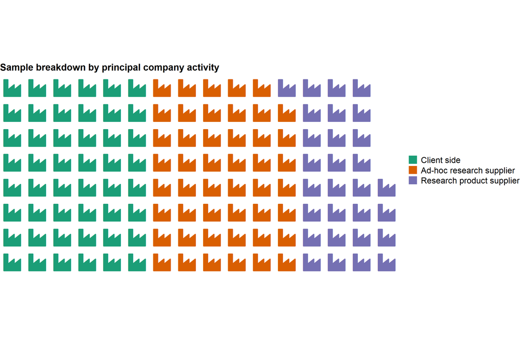

The respondent sample broke down as follows:- Client-side companies: 48; Ad-hoc research suppliers: 47; Research product suppliers: 29

### Seniority Level

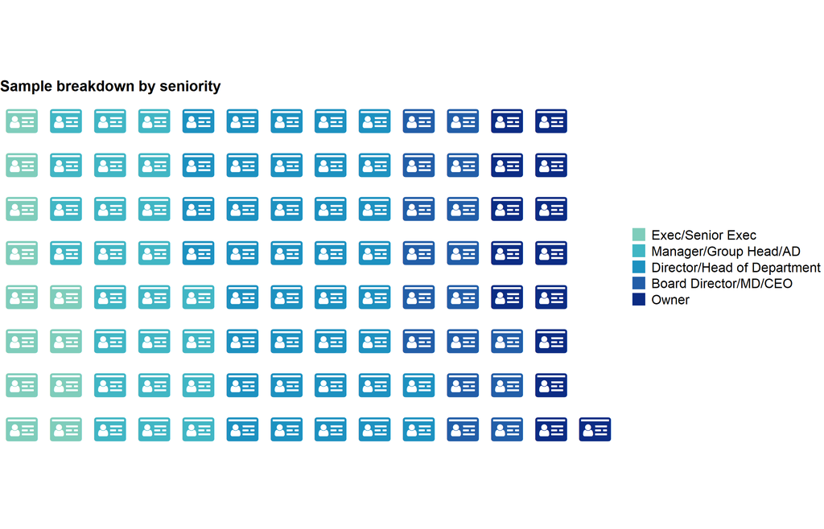

The respondent sample broke down as follows:- Execs/senior execs: 12; Managers/ADs: 24; Directors/Heads: 38; MD/CEO/Board: 17; Company owners: 14

### Years of Experience

[interactive chart not shown]

## Are media research jobs changing?

Question: *How do you think that your job has changed in the last five years*?

[interactive chart not shown]

## Time spent on tasks

Question: *How do you feel about the time you spend on the following*?

[interactive chart not shown]

## Client/Supplier Relationships

Question: *How good do you feel that your clients/suppliers are at the following*? (1 = poor, 5 = excellent)

### Empathy & communication

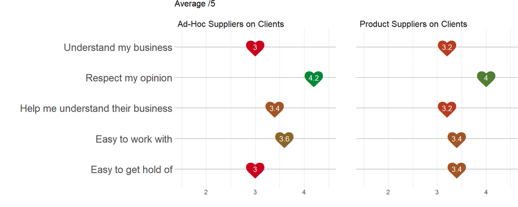

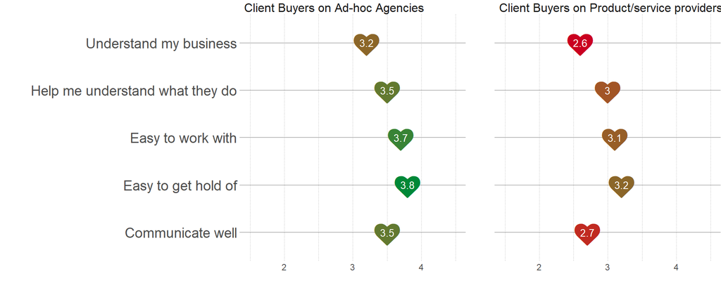

### Commercials and project management

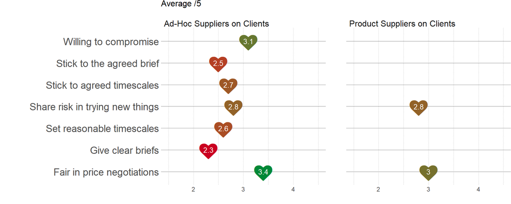

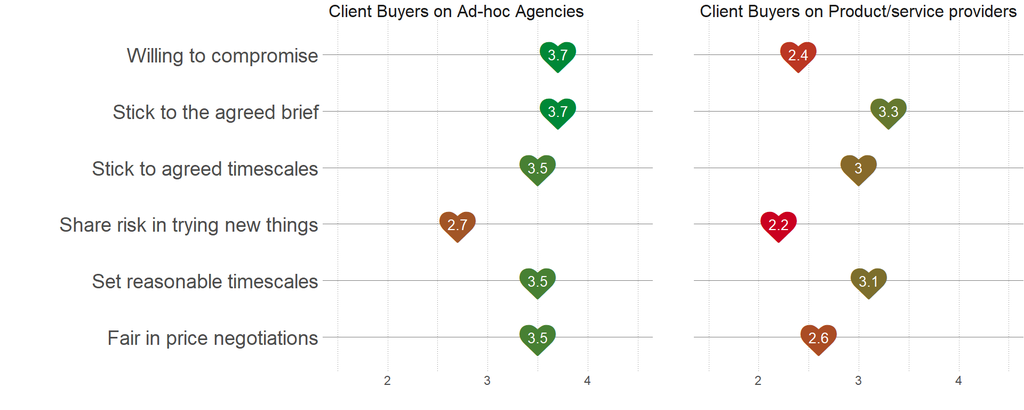

### Project outcomes

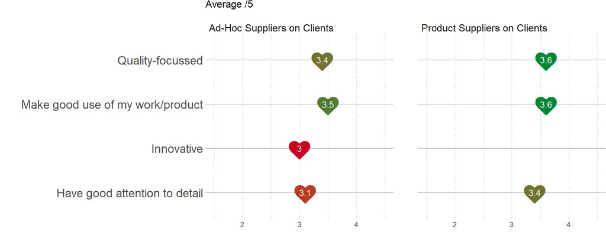

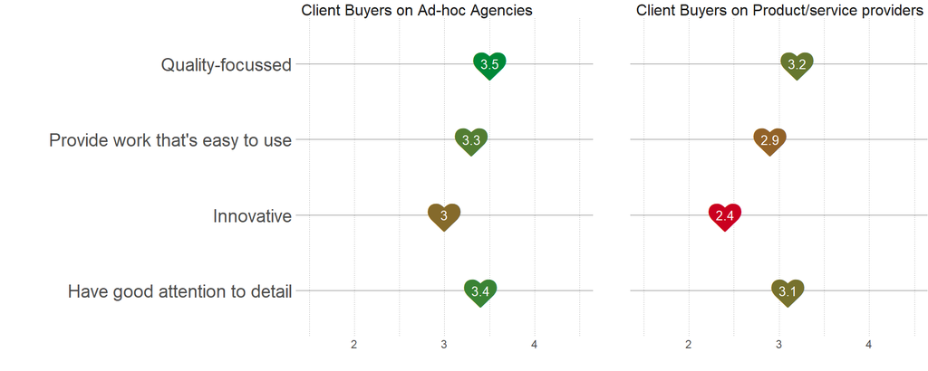

## Areas for improvement

Question: *Which of the following crimes do you think the media research industry may be guilty of*?

[interactive chart not shown]

## The year of…

### Potential Candidates

Question: *Which of the following are potential candidates for *Year of…* status in Media Research, in the coming years?"*

[interactive chart not shown]

### 2019

Question: *2019 will be the Year of…*

[interactive chart not shown]

### Write-Ins

*Most common words in “2019 the year of…” write ins*

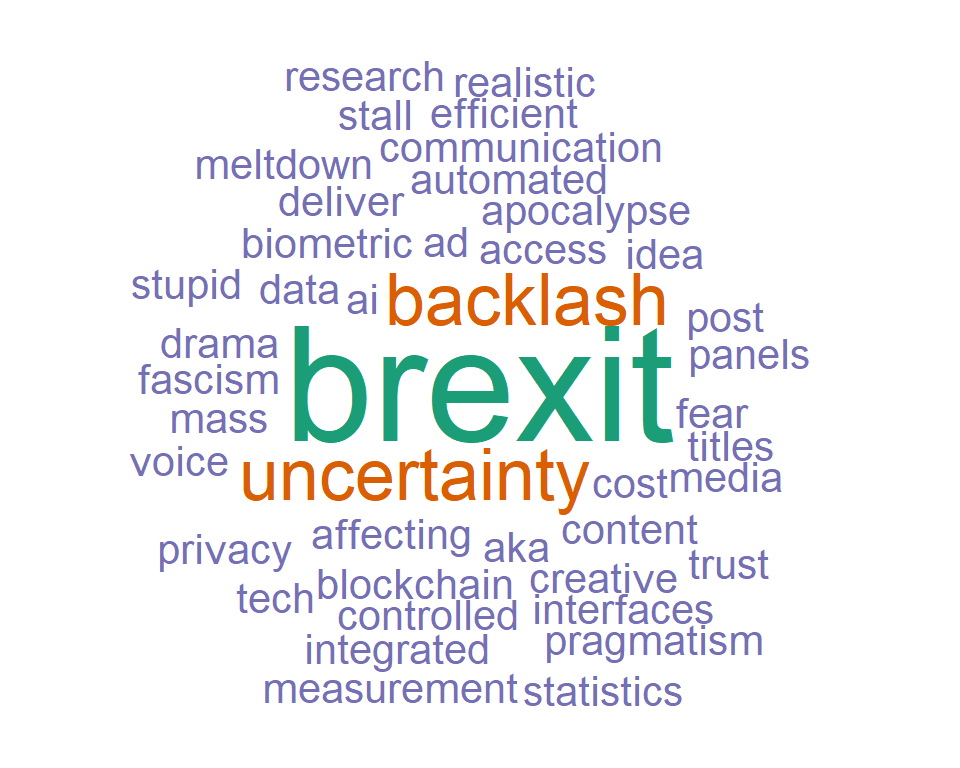

## Skills Shortages

Question: *Which of these skills do you think the media research business needs more of, and should it acquire them through training or hiring new staff?*

### Interactive

[interactive chart not shown]

### Need More

[interactive chart not shown]

### Adequately Resourced

[interactive chart not shown]

## Event Attendance

Question: *Please estimate how many times you have attended the following sorts of events in the last year.*

[interactive chart not shown]